# An Introduction to Phylogeography

Author

Paul Bastide

Published

October 17, 2025

# Analysis of the West Nile Virus (WNV) data with the Brownian Motion

In this practical script, we will analysis the West Nile Virus (WNV) data from [Pybus et al. 2012](https://www.pnas.org/doi/10.1073/pnas.1206598109), assuming a (strict) Brownian Motion model of geographical spread, and a fixed phylogenetic tree.

This script uses `R`, with the following packages, that you can install with the command `instal.packages`:

```r
library(ape)     # for phylogenetic tree manipulation
library(ggplot2) # for plotting results
library(ggExtra) # for ggMarginal bivariate plot
```

## The Brownian Motion (BM)

The goal of this first section is to simulate the trajectory of a simple Brownian Motion (BM).

### Univariate BM

The univariate BM with unit variance $(W_t)_{t \geq 0}$ is the continuous time process with stationary, independent increments that is such that:

- $W_0 = 0$;
- $W_t \mid W_s \sim \mathcal{N}(W_s, t-s)$ for any $t \geq s \geq 0$.

To simulate a trajectory of this process between $0$ ant $t_e$, we:

1. choose a regular grid on $[0,t_e]$ with step $dt = t_e / N$;
2. set $W_0 = 0$;
3. simulate increments $dW_n = W_{nt} - W_{(n-1)t} \sim \mathcal{N}(0, dt)$ for $1 \leq n \leq N$;
4. write $W_{n} = \sum_{i=1}^n dW_i$ for $1 \leq n \leq N$.

Justify this construction.

To simulate this process in `R`, we use the following code (to be completed).

**Question**

Write a function `simulate_bm(t_e,N)` that simulates a BM on $N$ points of the interval $[0,t_e]$. The function should return a dataframe, with a column containing the time, and a column containing the corresponding simulated values.

```r
simulate_bm <- function(t_e, N) {
  # 1. choose a regular grid on [0,T] with step dt = t_e / N
  dt <- t_e / N
  time <- seq(0, t_e, dt)
  # 2. define data frame and set W_0 = 0
  traj <- data.frame(time = time, value = rep(NA, N+1))
  [...]
  # 3. simulate increments dW_n \sim N(0, dt) for 1 <= n <= N
  [...]
  # 4. write W_n = \sum_{i=1}^n dW_i for 1 <= n <= N in the dataframe
  [...]
  # return dataframe
  return(traj)
}
```

**Solution**

```r
simulate_bm <- function(t_e, N) {
  # 1. choose a regular grid on [0,T] with step dt = t_e / N
  dt <- t_e / N
  time <- seq(0, t_e, dt)
  # 2. define data frame and set W_0 = 0
  traj <- data.frame(time = time, value = rep(NA, N+1))
  traj$value[1] <- 0
  # 3. simulate increments dW_n ~ N(0, dt) for 1 <= n <= N
  dW <- rep(NA, N)
  for (n in 1:N) {
    dW[n] <- rnorm(1, mean = 0, sd = sqrt(dt))
  }
  # 4. write W_n = \sum_{i=1}^n dW_i for 1 <= n <= N in the dataframe
  traj$value[-1] <- cumsum(dW)
  # return dataframe
  return(traj)
}
```

We can then simulate and plot the trajectory.

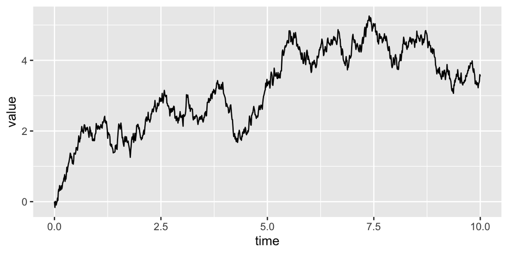

```r
t_e <- 10
N <- 1000
traj <- simulate_bm(t_e, N)
ggplot(traj, aes(x = time, y = value)) + geom_line()
```

**Question**

How can we simulate a BM with a given variance $\sigma^2$, and starting at a given value $\mu$ ?

**Solution**

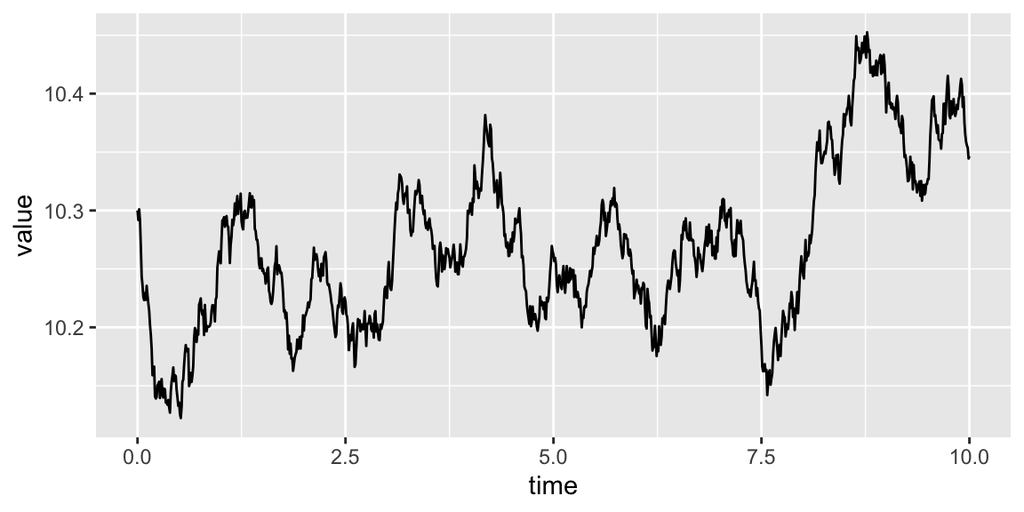

```r
sigma2 <- 0.01
mu <- 10.3
traj <- simulate_bm(t_e, N)
traj$value <- mu + sqrt(sigma2) * traj$value
ggplot(traj, aes(x = time, y = value)) + geom_line()
```

**Question**

What is the distribution of $W_{t_e}$ ? Build an histogram to show it empirically.

```r
nrep <- 1000
W_end <- data.frame(it = 1:nrep, value = rep(NA, nrep))

for (i in 1:nrep) {
  ## Fill in value
}

## Plot
ggplot(W_end, aes(x = value)) +
  geom_histogram(aes(y = ..density..), bins = 50) +
  stat_function(fun = dnorm, args = c([...], [...]))
```

**Solution**

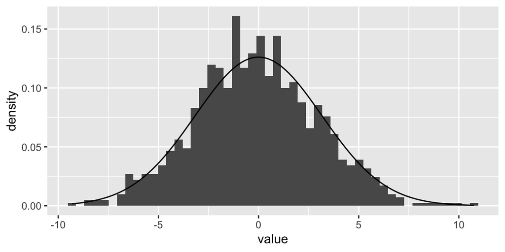

```r
nrep <- 1000
W_end <- data.frame(it = 1:nrep, value = rep(NA, nrep))
for (i in 1:nrep) {
  W_end$value[i] <- simulate_bm(t_e, N)$value[N]
}
ggplot(W_end, aes(x = value)) +
  geom_histogram(aes(y = after_stat(density)), bins = 50) +
  stat_function(fun = dnorm, args = c(0, sqrt(t_e)))
```

### Bi-variate BM

The bi-variate BM with unit variance $(\mathbf{W}_t)_{t \geq 0}$ is the continuous time process with stationary, independent increments that is such that:

- $\mathbf{W}_0 = \mathbf{0}$;
- $\mathbf{W}_t \mid \mathbf{W}_s \sim \mathcal{N}(\mathbf{W}_s, (t-s) \mathbf{I}_2)$ for any $t \geq s \geq 0$.

Note that this process is simply made of two independent BM on the $x$ and $y$ axes.

**Question**

Write a function `simulate_bm_bi(t_e,N)` that simulates a BM on $N$ points of the interval $[0,t_e]$. The function should return a dataframe, with a column containing the time, and a column containing the corresponding simulated x and y values.

```r
simulate_bm_bi <- function(t_e, N) {
  [...]
  return(traj)
}
```

**Solution**

```r
simulate_bm_bi <- function(t_e, N) {
  # simulate x axis
  traj_x <- simulate_bm(t_e, N)
  # simulate y axis
  traj_y <- simulate_bm(t_e, N)
  # merge
  traj <- merge(traj_x, traj_y, by = "time")
  return(traj)
}
```

We can then simulate and plot the trajectory.

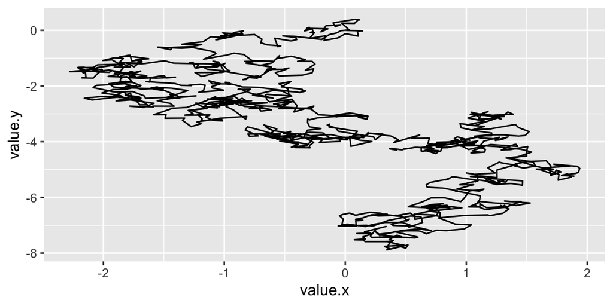

```r
traj <- simulate_bm_bi(t_e, N)
ggplot(traj, aes(x = value.x, y = value.y)) + geom_path()
```

**Question**

How can we simulate a BM with a given variance $\Sigma$, and starting at a given value $\boldsymbol{\mu}$ ?

**Solution**

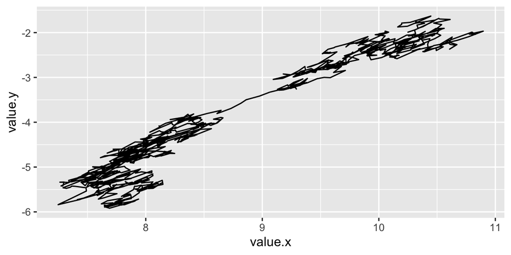

```r
sigma2 <- matrix(c(0.55, 0.45, 0.45, 0.55), ncol = 2)
chol_sigma2 <- chol(sigma2)
stopifnot(isTRUE(all.equal(t(chol_sigma2) %*% chol_sigma2, sigma2)))
mu <- c(10.3, -2.3)
traj <- simulate_bm_bi(t_e, N)
traj[, c(2, 3)] <- sweep(as.matrix(traj[, c(2, 3)]) %*% chol_sigma2, 2, -mu)
ggplot(traj, aes(x = value.x, y = value.y)) + geom_path()
```

**Question**

What is the distribution of $\mathbf{W}_{t_e}$ ? Build an histogram to show it empirically.

```r
nrep <- 1000
W_end <- data.frame(it = 1:nrep, value = rep(NA, nrep))

for (i in 1:nrep) {
  ## Fill in value
}

## Plot
ggplot(W_end, aes(x = value)) +
  geom_histogram(aes(y = ..density..), bins = 50) +
  stat_function(fun = dnorm, args = c([...], [...]))
```

**Solution**

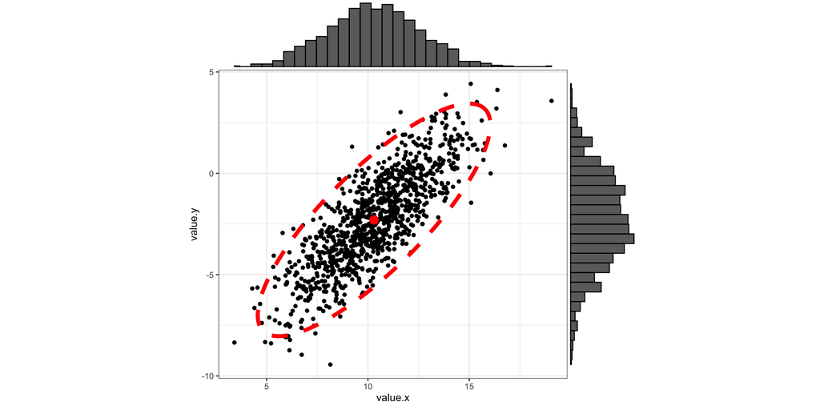

```r
nrep <- 1000
W_end <- data.frame(it = 1:nrep, value.x = rep(NA, nrep), value.y = rep(NA, nrep))
for (i in 1:nrep) {
  traj <- simulate_bm_bi(t_e, N)
  traj[, c(2, 3)] <- sweep(as.matrix(traj[, c(2, 3)]) %*% chol_sigma2, 2, -mu)
  W_end[i, c(2, 3)] <- traj[N, c(2, 3)]
}
datEllipse <- ellipse::ellipse(t_e * sigma2, center = mu, level = 0.95)
p <-
  ggplot(W_end, aes(x = value.x, y = value.y)) +
  geom_point() +
  geom_point(data = data.frame(x = mu[1], y = mu[2]), aes(x = x, y = y), size = 4, col = "red") +
  geom_path(aes(x = x, y = y), data = datEllipse, linewidth = 2, linetype = 2, col = "red") +
  coord_fixed(ratio = 1) +
  theme_bw()
ggMarginal(p, type = "histogram")
```

### BM on a tree

We can then simulate a BM on a phylogenetic tree.

We first need to simulate a tree using function `rphylo` from the `ape` package:

```r
set.seed(1899)              # set seed for reproducibility
tree <- rphylo(5, 0.5, 0.1) # simulate a tree
tree                        # show tree object
```

```
Phylogenetic tree with 5 tips and 4 internal nodes.

Tip labels:
  t1, t2, t3, t4, t5

Rooted; includes branch length(s).
```

The `phylo` object contains all the information needed about the tree (see `help(phylo)`), including branch lengths, which we take as given in units of time. We can re-order the tree so that its edges are numbered from the root to the tips (in a [preorder](https://en.wikipedia.org/wiki/Tree_traversal#Pre-order,_NLR)).

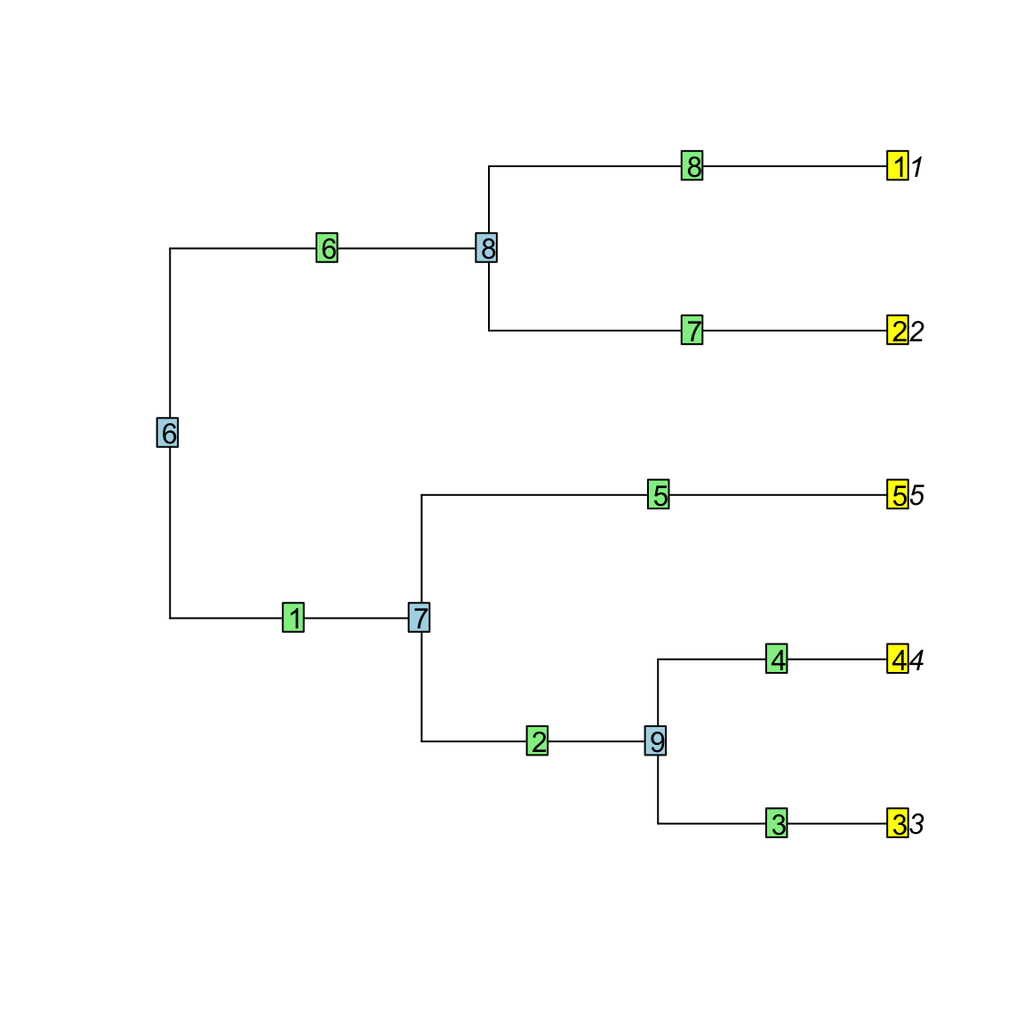

```r
tree <- reorder(tree)
plot(tree)
edgelabels()
nodelabels()
tiplabels()
```

The `tree$edge` field is a table with 2 columns and as many rows as there are edges. Each line gives the number of the parent node and the child node of the edge.

**Question**

Give the parent node and child node of edge number `5`. Find it on the tree.

**Solution**

```r
tree$edge[5, ]
```

```
[1] 7 5
```

Its parent node is:

```r
tree$edge[5, 1]
```

```
[1] 7
```

and its child node is:

```r
tree$edge[5, 2]
```

```
[1] 5
```

**Question**

Find the parent node on the tree of node number `3`. Find it on the tree.

**Solution**

To find the parent node of node number `3`, we need to find it in the second column of `tree$edge`:

```r
which(tree$edge[, 2] == 3) # find the edge that ends at node 3
```

```
[1] 3
```

The parent of node `3` is then given by the first column of this edge:

```r
tree$edge[tree$edge[, 2] == 3, 1] # find the parent node of node 3
```

```
[1] 9
```

**Question**

Find the edge that is just before edge number `5` on the tree. What about the edge that is just before edge number `1` ? Find them on the tree.

**Solution**

```r
which(tree$edge[5, 1] == tree$edge[, 2])
```

```
[1] 1
```

We do the same for edge `1` :

```r
which(tree$edge[1, 1] == tree$edge[, 2])
```

```
integer(0)
```

and find that this edge has no parent edge, as it starts at the root of the tree.

**Question**

What is the length of edge number `3` ?

**Solution**

The length of edge number `3` is given by:

```r
tree$edge.length[3]
```

```
[1] 0.1571309
```

To simulate a BM on the tree, we need to traverse the branches of the tree in a preorder. On a given branch, we can simulate a BM in time. When the branch ends at a given node, it splits into two branches, and we can start two new independent BM, starting at the ending value of the current branch.

**Question**

Simulate a univariate BM on the `tree` generated above by traversing the edges of the tree.

```r
## choose a time step
dt <- 0.001
## choose starting value
mu <- 1.3
## Create a data frame with the simulated trajectory
dftree <- data.frame(value = numeric(0),       # position of the BM
                     time = numeric(0),        # time elapsed since root
                     edge = numeric(0))        # number of the edge of the tree
## traverse the tree from edge to edge
for (i in 1:nrow(tree$edge)) {
  # simulate a BM starting at (0,0) on the current branch
  t_branch <- tree$edge.length[i]
  N_branch <- floor(t_branch / dt)
  current_BM <- [...]
  # find the parent edge of the starting node of the current edge
  parent_edge <-[...]
  # case where current edge does not a parent edge
  if (length(parent_edge) == 0) {
    # add starting value mu
    current_BM$value <- [...]s
  } else { # case where current edge do have a parent edge
    # find last value on the parent branch
    dfparent <- dftree[dftree$edge == parent_edge, ]
    last_parent <- dfparent[nrow(dfparent), ]
    # add last value of parent as starting value of the branch
    current_BM$value <- [...]
    current_BM$time <- [...]
  }
  # fill in the dataframe
  dfbranch <-  data.frame(value = current_BM$value,
                          time = current_BM$time,
                          edge = i)
  # update dftree
  dftree <- rbind(dftree, dfbranch)
}
```

**Solution**

```r
## choose a time step
dt <- 0.001
## choose starting value
mu <- 1.3
## Create a data frame with the simulated trajectory
dftree <- data.frame(value = numeric(0),       # position of the BM
                     time = numeric(0),        # time elapsed since root
                     edge = numeric(0))        # number of the edge of the tree
## traverse the tree from edge to edge
for (i in 1:nrow(tree$edge)) {
  # simulate a BM starting at (0,0) on the current branch
  t_branch <- tree$edge.length[i]
  N_branch <- floor(t_branch / dt)
  current_BM <- simulate_bm(t_branch, N_branch)
  # find the parent edge of the starting node of the current edge
  parent_edge <- which(tree$edge[i, 1] == tree$edge[, 2])
  # case where current edge does not a parent edge
  if (length(parent_edge) == 0) {
    # add starting value mu
    current_BM$value <- current_BM$value + mu
  } else { # case where current edge do have a parent edge
    # find last value on the parent branch
    dfparent <- dftree[dftree$edge == parent_edge, ]
    last_parent <- dfparent[nrow(dfparent), ]
    # add last value of parent as starting value of the branch
    current_BM$value <- current_BM$value + last_parent$value
    current_BM$time <- current_BM$time + last_parent$time
  }
  # fill in the dataframe
  dfbranch <-  data.frame(value = current_BM$value,
                          time = current_BM$time,
                          edge = i)
  # update dftree
  dftree <- rbind(dftree, dfbranch)
}
```

We can then plot the univariate BM in time.

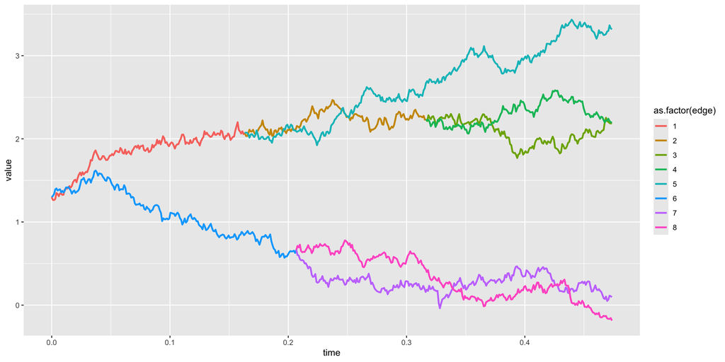

```r
p <- ggplot(dftree, aes(time, value, color = as.factor(edge))) +
  geom_path(linewidth = 1)
p
```

Compare the simulation with the tree structure.

We can then simulate a bi-variate BM on the tree.

**Question**

Using a similar recursion on the tree, simulate a bivariate BM on the `tree` generated above.

```r
## choose a time step
dt <- 0.001
## choose starting value
mu <- c(1.3, -2.4)
## Create a data frame with the simulated trajectory
dftree <- data.frame(value.x = numeric(0),     # x position of the BM
                     value.y = numeric(0),     # y position of the BM
                     time = numeric(0),        # time elapsed since root
                     edge = numeric(0))        # number of the edge of the tree
## traverse the tree from edge to edge
for (i in 1:nrow(tree$edge)) {
  [...]
}
```

**Solution**

```r
## choose a time step
dt <- 0.001
## choose starting value
mu <- c(1.3, -2.4)
## Create a data frame with the simulated trajectory
dftree <- data.frame(value.x = numeric(0),     # x position of the BM
                     value.y = numeric(0),     # y position of the BM
                     time = numeric(0),        # time elapsed since root
                     edge = numeric(0))        # number of the edge of the tree
## traverse the tree from edge to edge
for (i in 1:nrow(tree$edge)) {
  # simulate a BM starting at (0,0) on the current branch
  t_branch <- tree$edge.length[i]
  N_branch <- floor(t_branch / dt)
  current_BM <- simulate_bm_bi(t_branch, N_branch)
  # find the parent edge of the starting node of the current edge
  parent_edge <- which(tree$edge[i, 1] == tree$edge[, 2])
  # case where current edge does not a parent edge
  if (length(parent_edge) == 0) {
    # add starting value mu
    current_BM$value.x <- current_BM$value.x + mu[1]
    current_BM$value.y <- current_BM$value.y + mu[2]
  } else { # case where current edge do have a parent edge
    # find last value on the parent branch
    dfparent <- dftree[dftree$edge == parent_edge, ]
    last_parent <- dfparent[nrow(dfparent), ]
    # add last value of parent as starting value of the branch
    current_BM$value.x <- current_BM$value.x + last_parent$value.x
    current_BM$value.y <- current_BM$value.y + last_parent$value.y
    current_BM$time <- current_BM$time + last_parent$time
  }
  # fill in the dataframe
  dfbranch <-  data.frame(value.x = current_BM$value.x,
                          value.y = current_BM$value.y,
                          time = current_BM$time,
                          edge = i)
  # update dftree
  dftree <- rbind(dftree, dfbranch)
}
```

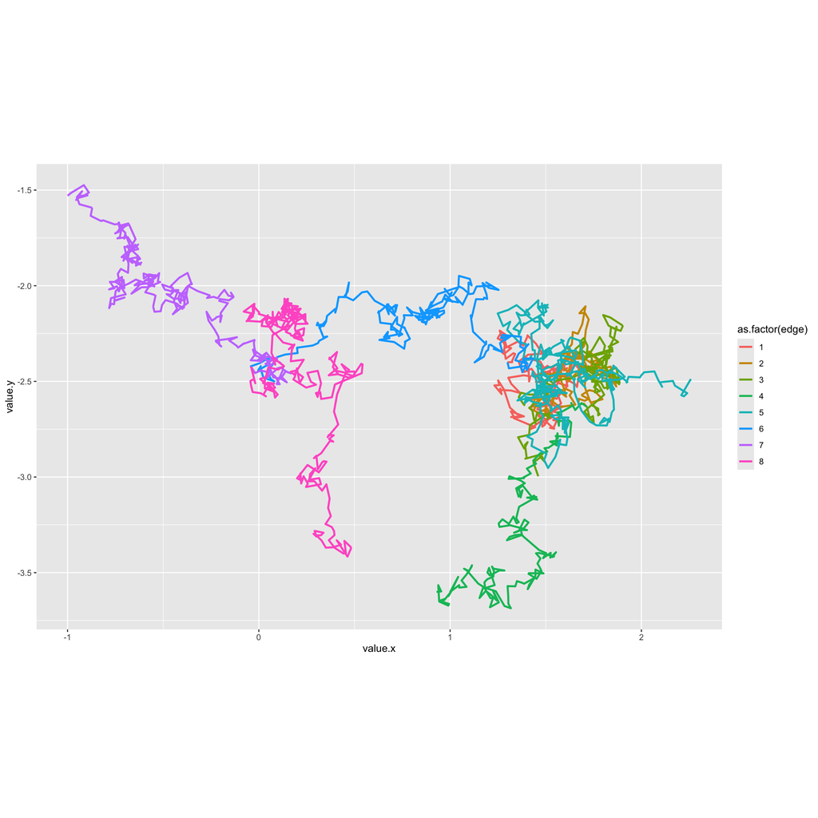

```r
p <- ggplot(dftree, aes(value.x, value.y, color = as.factor(edge))) +
  geom_path(linewidth = 1) +
  coord_fixed(ratio = 1)
p
```

## Analysis of the WNV dataset

### Loading the data

We use the data available in this [GitHub repository](https://github.com/pbastide/cauchy_paper).

We assume here that a phylogenetic tree of the virus has already been inferred, based on genetic data. It can be loaded in `R` using function `read.tree` from package `ape`.

```r
tree <- read.tree("https://raw.githubusercontent.com/pbastide/cauchy_paper/refs/heads/main/data/Pybus_et_al_2012_Data/WNV_GTR_gamma_MCC.newick")
tree
```

```
Phylogenetic tree with 104 tips and 103 internal nodes.

Tip labels:
  AF202541_Hs_1999.66, FJ151394_Cb_1999, DQ164188_Cb_2003, AF404756_Cb_2000, DQ164194_Cb_2001, AF404754_Cp_2000, ...

Rooted; includes branch length(s).
```

Each tip of the tree represents a variant of the virus sampled in one individual. The tree has time information in years, so that it can be dated, as in the plot below.

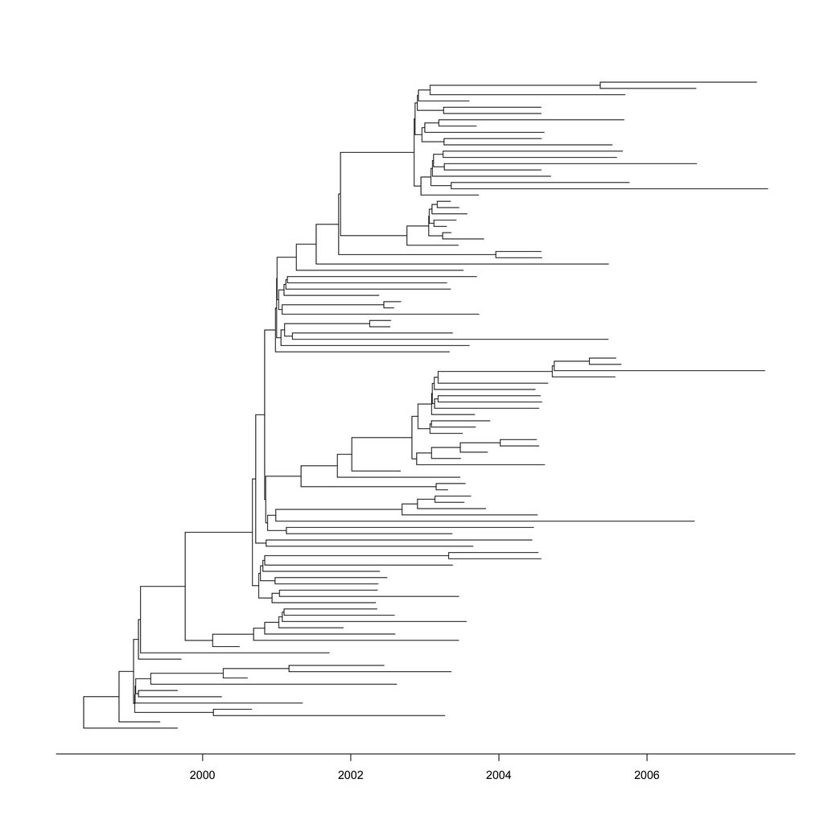

```r
plot(tree, show.tip.label = FALSE)
axisPhylo(root.time = 1998.394, backward = FALSE)
```

We then need to know the geographical localisation of the virus when they were sampled. These are recorded as latitude and longitude information in the following table:

```r
dat <- read.table("https://raw.githubusercontent.com/pbastide/cauchy_paper/refs/heads/main/data/Pybus_et_al_2012_Data/WNV_lat_long.txt",
                  header = TRUE)
head(dat)
```

```
            traits   lat    long
1 WG007_Hs_2005.59 31.82 -106.56
2 WG009_Hs_2005.67 32.28 -106.74
3 WG011_Hs_2006.66 31.78 -106.50
4 WG013_Hs_2007.48 31.84 -106.53
5 WG024_Hs_2003.53 33.81 -117.83
6 WG080_Hs_2004.56 34.22 -118.44
```

**Question**

The names in `dat$traits` should match the tip labels of the tree in `tree$tip.label`. Using function `match`, re-order the lines of `dat` to make sure they are in the same as the tip labels. Then plot the tree and data using function `phydataplot`.

```r
## Match data and tree
match(tree$tip.label, dat$traits)
[...]

## Plot tree and data
plot(tree, show.tip.label = FALSE, x.lim = 25)
phydataplot(dat[, "lat", drop = F], tree, offset = 1, scaling = 0.1)
phydataplot(dat[, "long", drop = F], tree, offset = 15, scaling = 0.05)
```

**Solution**

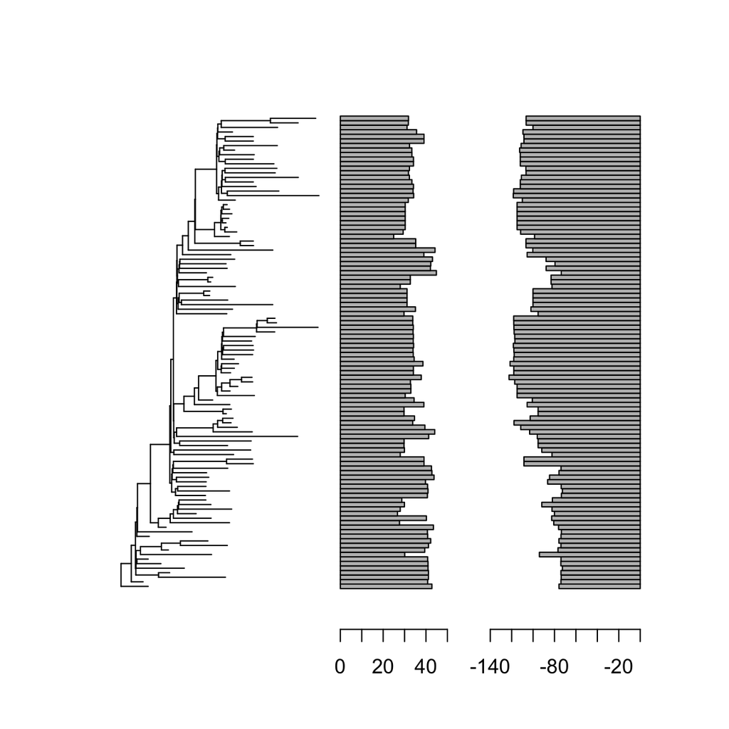

```r
## Match data and tree
dat <- dat[match(tree$tip.label, dat$traits), ]
rownames(dat) <- dat$traits

## Plot tree and data
plot(tree, show.tip.label = FALSE, x.lim = 25)
phydataplot(dat[, "lat", drop = F], tree, offset = 1, scaling = 0.1)
phydataplot(dat[, "long", drop = F], tree, offset = 15, scaling = 0.05)
```

The two traits correspond to latitude and longitude. To plot these points on a map, we can use packages `sf` and `rnaturalearth`.

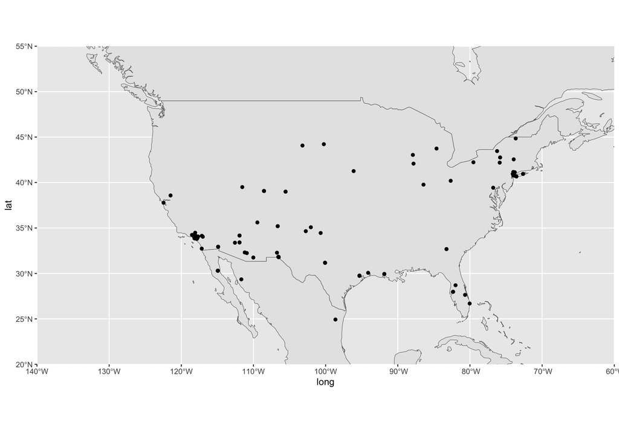

```r
library("sf")
library("rnaturalearth")
north_america <- ne_countries(scale = "medium",
                              returnclass = "sf",
                              continent = "north america")
ggplot(data = north_america) +
  geom_sf() +
  coord_sf(xlim = c(-140, -60), ylim = c(20, 55), expand = FALSE) +
  geom_point(data = dat, aes(x = long, y = lat))
```

This map represents the position of the sampled viruses, at all times. Our question are:

- where did the virus emerge for the first time ?
- how did it spread on the map ?

### Root position

To find the most probable root position, we fit a multivariate BM to the data.

Recall that, using the BM, the matrix of data has the matrix normal distribution:
$$\mathbf{Y} \sim \mathcal{MN}_{n,2}(\mathbf{1}_n\boldsymbol{\mu}^T, \mathbf{V}, \mathbf{\Sigma})$$
with $\boldsymbol{\mu}$ the vector of the root position, $\mathbf{\Sigma}$ the variance matrix of the BM, and $\mathbf{V}$ the matrix given by the tree.

The maximum likelihood formulas for the parameters are then:
$$\hat{\boldsymbol{\mu}}^T
= (\mathbf{1}_n^T \mathbf{V}^{-1} \mathbf{1}_n)^{-1} \mathbf{1}_n^T \mathbf{V}^{-1} \mathbf{Y}$$
$$\hat{\mathbf{\Sigma}}
= \frac{1}{n-1} (\mathbf{Y} - \mathbf{1}_n\hat{\boldsymbol{\mu}}^T)^T \mathbf{V}^{-1} (\mathbf{Y} - \mathbf{1}_n\hat{\boldsymbol{\mu}}^T)$$

The tree matrix $\mathbf{V}$ can be obtained from `ape` function `vcv`:

```r
V <- vcv(tree)
V[1:3,1:3]
```

```
                    AF202541_Hs_1999.66 FJ151394_Cb_1999 DQ164188_Cb_2003
AF202541_Hs_1999.66            1.266477        0.0000000        0.0000000
FJ151394_Cb_1999               0.000000        1.0295882        0.4775296
DQ164188_Cb_2003               0.000000        0.4775296        4.8759063
```

**Question**

What are the interpretations of the coefficients of $\mathbf{V}$ ? On this tree, can you find the year of the root ? What does this mean for the epidemic ?

**Solution**

$V_{ij}$ is the time between the root and the most recent ancestor of tips $i$ and $j$. On the diagonal, $V_{ii}$ is the time between the root and the tip $i$. Because there are dates associated with each tip, we can find the year of the root with a subtraction:

```r
diag(V)[c(1, 8, 12)]
```

```
AF202541_Hs_1999.66 AY289214_Hs_2002.62 AF196835_Pc_1999.71
           1.266477            4.226477            1.316477
```

```r
1999.66 - diag(V)[1]
```

```
AF202541_Hs_1999.66
           1998.394
```

```r
2002.62 - diag(V)[8]
```

```
AY289214_Hs_2002.62
           1998.394
```

```r
1999.71 - diag(V)[12]
```

```
AF196835_Pc_1999.71
           1998.394
```

This means that the epidemic first appear in the US in year $1998.394$.

(Bonus: what does the `.394` means ?)

**Question**

Implement the formulas above to find $\hat{\boldsymbol{\mu}}$ and $\hat{\mathbf{\Sigma}}$.

```r
## data
Y <- as.matrix(dat[, c(2, 3)])
ndata <- nrow(Y)
ones = rep(1, ndata)

Vinv <- [...]

## mu hat
mu_hat <- [...]

## Sigma hat
sigma_hat <- [...]
```

**Solution**

```r
## data
Y <- as.matrix(dat[, c(2, 3)])
ndata <- nrow(Y)
ones = rep(1, ndata)

Vinv <- solve(V)

## mu hat
mu_hat <- solve(t(ones) %*% Vinv %*% ones) %*% t(ones) %*% Vinv %*% Y

## Sigma hat
sigma_hat <- 1/(ndata-1) * t(Y - ones %*% mu_hat) %*% Vinv %*% (Y - ones %*% mu_hat)
```

**Question**

Plot the inferred root position on the map. Where did the virus emerge in the US ? Does this make sense ?

**Solution**

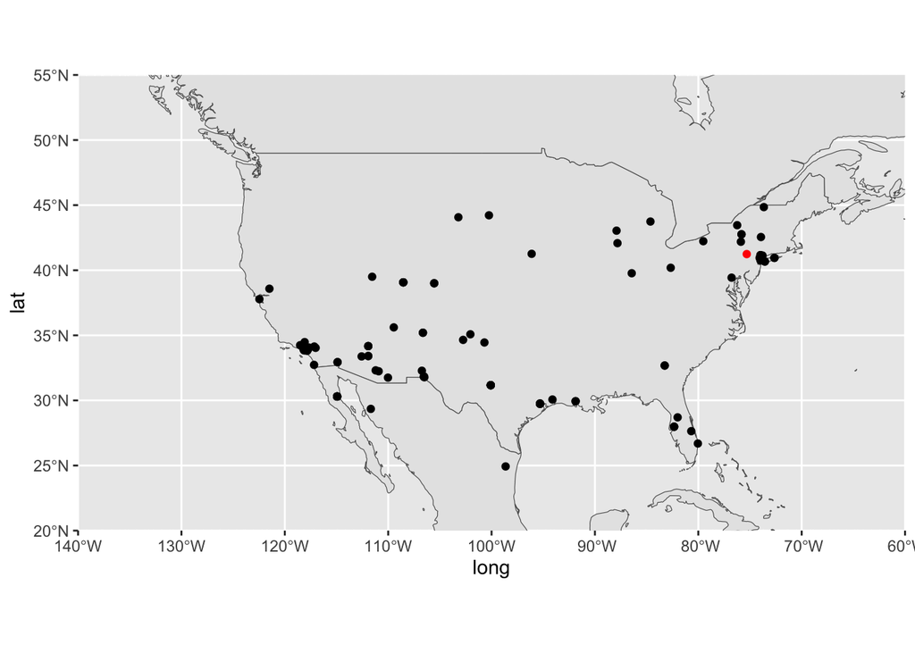

```r
## data
ggplot(data = north_america) +
  geom_sf() +
  coord_sf(xlim = c(-140, -60), ylim = c(20, 55), expand = FALSE) +
  geom_point(data = dat, aes(x = long, y = lat)) +
  geom_point(data = mu_hat, aes(x = long, y = lat), col = "red")
```

### Ancestral state reconstruction

Writing $\mathbf{Z}$ the matrix of states at ancestral nodes, remind the formula:
$$\begin{pmatrix}
\mathbf{Z}_{\cdot,1}\\
\mathbf{Z}_{\cdot,2}\\
\mathbf{Y}_{\cdot,1}\\
\mathbf{Y}_{\cdot,2}
\end{pmatrix}
\sim
\mathcal{N}\left(
\begin{pmatrix}
\mu_1\mathbf{1}_m\\
\mu_2\mathbf{1}_m\\
\mu_1\mathbf{1}_n\\
\mu_2\mathbf{1}_n
\end{pmatrix}
,
\begin{pmatrix}
\Sigma_{11}\mathbf{V}_{ZZ} & \Sigma_{12}\mathbf{V}_{ZZ} & \Sigma_{11}\mathbf{V}_{ZY} & \Sigma_{12}\mathbf{V}_{ZY}\\
\Sigma_{21}\mathbf{V}_{ZZ} & \Sigma_{22}\mathbf{V}_{ZZ} & \Sigma_{21}\mathbf{V}_{ZY} & \Sigma_{22}\mathbf{V}_{ZY}\\
\Sigma_{11}\mathbf{V}_{YZ} & \Sigma_{12}\mathbf{V}_{YZ} & \Sigma_{11}\mathbf{V}_{YY} & \Sigma_{12}\mathbf{V}_{YY}\\
\Sigma_{21}\mathbf{V}_{YZ} & \Sigma_{22}\mathbf{V}_{YZ} & \Sigma_{21}\mathbf{V}_{YY} & \Sigma_{22}\mathbf{V}_{YY}
\end{pmatrix}
\right)$$

In the formula above, we need the full $\mathbf{V}$ matrix, for both the $\mathbf{Z}$ and the $\mathbf{Y}$.

We first label all the nodes in the tree:

```r
tree <- makeNodeLabel(tree)
tree
```

```
Phylogenetic tree with 104 tips and 103 internal nodes.

Tip labels:
  AF202541_Hs_1999.66, FJ151394_Cb_1999, DQ164188_Cb_2003, AF404756_Cb_2000, DQ164194_Cb_2001, AF404754_Cp_2000, ...
Node labels:
  Node1, Node2, Node3, Node4, Node5, Node6, ...

Rooted; includes branch length(s).
```

Then we compute the full matrix. This time, we construct it naively by hand.

```r
## Get the number of tips and internal nodes
ntips <- length(tree$tip.label)
nnodes <- length(tree$node.label)
## Contruct the void matrix
Vfull <- matrix(NA, ncol =  nnodes + ntips, nrow = nnodes + ntips)
## Name it with node first, then tips
tipandnodeslabels <- c(tree$node.label, tree$tip.label)
colnames(Vfull) <- rownames(Vfull) <- tipandnodeslabels
## get all ancestors for each pair of node / tip
all_ancestors <- mrca(tree, full = TRUE)
# note: this has tips first, then nodes, so that we re-order it first
all_ancestors_nodes_tips <- matrix(NA, ncol =  nnodes + ntips, nrow = nnodes + ntips)
all_ancestors_nodes_tips[1:nnodes, 1:nnodes] <- all_ancestors[ntips+1:nnodes, ntips+1:nnodes]
all_ancestors_nodes_tips[1:nnodes, nnodes+1:ntips] <- all_ancestors[ntips+1:nnodes, 1:ntips]
all_ancestors_nodes_tips[nnodes+1:ntips, 1:nnodes] <- all_ancestors[1:ntips, ntips+1:nnodes]
all_ancestors_nodes_tips[nnodes+1:ntips, nnodes+1:ntips] <- all_ancestors[1:ntips, 1:ntips]
## Fill it
for (i in 1:(nnodes + ntips)) {
  for (j in 1:(nnodes + ntips)) {
    ancestor_ij <- all_ancestors_nodes_tips[i,j]      # ancestor of i and j
    t_ij <- node.depth.edgelength(tree)[ancestor_ij]  # time between root and ancestor
    Vfull[i,j] <- t_ij                                # fill matrix
  }
}
## separate between nodes and tips
VZZ <- Vfull[1:nnodes, 1:nnodes]
VZY <- Vfull[1:nnodes, nnodes+1:ntips]
VYY <- Vfull[nnodes+1:ntips, nnodes+1:ntips]
```

We can check that the sub-matrix with the tips is the same as the matrix we previously had:

```r
all(VYY == V)
```

```
[1] TRUE
```

**Question**

Using the values of $\boldsymbol{\mu}$ and $\mathbf{\Sigma}$ estimated in the previous section, compute the expectation and mean of the full vector $(\mathbf{Z}, \mathbf{Y})$. You can use the Kronecker product as presented below.

```r
## Kronecker product
A <- matrix(1:4, ncol = 2)
B <- matrix(10, ncol = 3, nrow = 3)
A
```

```
     [,1] [,2]
[1,]    1    3
[2,]    2    4
```

```r
B
```

```
     [,1] [,2] [,3]
[1,]   10   10   10
[2,]   10   10   10
[3,]   10   10   10
```

```r
kronecker(A, B)
```

```
     [,1] [,2] [,3] [,4] [,5] [,6]
[1,]   10   10   10   30   30   30
[2,]   10   10   10   30   30   30
[3,]   10   10   10   30   30   30
[4,]   20   20   20   40   40   40
[5,]   20   20   20   40   40   40
[6,]   20   20   20   40   40   40
```

**Solution**

```r
mZ <- kronecker(t(mu_hat), rep(1, nnodes))
mY <- kronecker(t(mu_hat), rep(1, ntips))
SZZ <- kronecker(sigma_hat, VZZ)
SZY <- kronecker(sigma_hat, VZY)
SYY <- kronecker(sigma_hat, VYY)
```

For the conditional distribution of the ancestral states knowing the tip positions, remind that we have:
$$\mathbf{Z} \mid \{\mathbf{Y} = \mathbf{y}\}
\sim
\mathcal{N}\left(
\bar{\mathbf{m}}
,
\bar{\mathbf{S}}
\right)$$

$$\bar{\mathbf{m}}
=
\mathbf{m}_Z + \mathbf{S}_{ZY} \mathbf{S}_{YY}^{-1} (\mathbf{y} - \mathbf{m}_Y)
\quad
\bar{\mathbf{S}}
=
\mathbf{S}_{ZZ} - \mathbf{S}_{ZY} \mathbf{S}_{YY}^{-1}\mathbf{S}_{YZ}$$

**Question**

For each node $i$, compute the conditional mean of the ancestral position at this node.

```r
## full conditionals
bar_m <- [...]

## re-organize to find the marginals
cond_mean_Z <- [...]
```

**Solution**

```r
## full conditionals
bar_m <- mZ + SZY %*% solve(SYY) %*% (as.vector(Y) - mY)

## re-organize to find the marginals
cond_mean_Z <- matrix(bar_m, ncol = 2, byrow = FALSE)
```

### Plot in Evolaps

We use [evolaps](https://www.evolaps.org/evolaps42/index.html) to plot the reconstructe states dynamically.

We first need to export the data using the correct format. This requires package `treeio`:

```r
if (!requireNamespace("BiocManager", quietly=TRUE))
    install.packages("BiocManager")
BiocManager::install("treeio")
```

Then record the annotated tree in your local repository:

```r
rec_table <- list(node = seq_len(ntips + nnodes))

## Positions
rec_table[["location1"]] <- c(dat[, "lat"], cond_mean_Z[, 1])
rec_table[["location2"]] <- c(dat[, "long"], cond_mean_Z[, 2])
## Reconstructions
rec_table[["location1_median"]] <- c(rep(NA, ntips), cond_mean_Z[, 1])
rec_table[["location2_median"]] <- c(rep(NA, ntips), cond_mean_Z[, 2])


## treedata
rec_table <- treeio::as_tibble(rec_table)
tree_tibble <- treeio::as_tibble(tree)
tree_data <- treeio::full_join(tree_tibble, rec_table, by = 'node')
tree_data <- treeio::as.treedata(tree_data)

treeio::write.beast(tree_data, file = "tree_MCC.tree", tree.name = "TREE1")
```

Finally, read the tree in Evolaps.

### Ancestral state reconstruction - variances

**Question**

For each node $i$, compute the conditional variance of the ancestral position at this node.

```r
## full conditionals
bar_S <- [...]

## re-organize to find the marginals
cond_var_Z <- list()
for (i in 1:nnodes) {
  cond_var_Z[[i]] <- [...]
}
```

**Solution**

```r
## full conditionals
bar_S <- SZZ - SZY %*% solve(SYY) %*% t(SZY)

## re-organize to find the marginals
cond_var_Z <- list()
for (i in 1:nnodes) {
  cond_var_Z[[i]] <- matrix(c(bar_S[i,i], bar_S[i, nnodes+i],
                              bar_S[nnodes+i, i], bar_S[nnodes+i, nnodes+i]),
                            ncol = 2)
}
```

**Question**

For each node $i$, compute the confidence ellipse using package `ellipse`.

```r
level <- 0.80

conf_loc <- list()
for (i in 1:nnodes) {
  conf_loc[[i]] <- ellipse::ellipse([...])
}
```

**Solution**

```r
level <- 0.80

conf_loc <- list()
for (i in 1:nnodes) {
  conf_loc[[i]] <- ellipse::ellipse(cond_var_Z[[i]],
                                    center = cond_mean_Z[i, ],
                                    level = level)
}
```

Then record the annotated tree in your local repository:

```r
rec_table <- list(node = seq_len(ntips + nnodes))

## Positions
rec_table[["location1"]] <- c(dat[, "lat"], cond_mean_Z[, 1])
rec_table[["location2"]] <- c(dat[, "long"], cond_mean_Z[, 2])
## Reconstructions
rec_table[["location1_median"]] <- c(rep(NA, ntips), cond_mean_Z[, 1])
rec_table[["location2_median"]] <- c(rep(NA, ntips), cond_mean_Z[, 2])
## ellipses
trait_name_lat <- paste0("location1_", level * 100, "%HPD")
trait_name_long <- paste0("location2_", level * 100, "%HPD")
rec_table[[paste0(trait_name_lat, "_", 1)]] <- c(rep(NA, ntips), lapply(conf_loc, function(cc) cc[, 1]))
rec_table[[paste0(trait_name_long, "_", 1)]] <- c(rep(NA, ntips), lapply(conf_loc, function(cc) cc[, 2]))

## treedata
rec_table <- treeio::as_tibble(rec_table)
tree_tibble <- treeio::as_tibble(tree)
tree_data <- treeio::full_join(tree_tibble, rec_table, by = 'node')
tree_data <- treeio::as.treedata(tree_data)

treeio::write.beast(tree_data, file = "tree_MCC.tree", tree.name = "TREE1")
```

Finally, read the tree in Evolaps. Are these confidence regions satisfactory ?